# Using Voice Features to Predict Extraversion and Openness

Josh Winnes, Andrew Howe, and Jeremiah Cho

2025-04-05

# 1. Abstract

# 2. Introduction

We are interested in the relationship between a speaker’s voice and their personality traits. Specifically, we are interested in seeing if quantifiable voice features (such as fundamental frequency or zero-crossing rate) can be used to accurately measure the components of a speaker’s personality. One common way of quantifying a speaker’s personality is to use the OCEAN model. This model is analogous to the primary colors in color theory. The idea is that one’s unique personality can be divided up into different proportions of the five main personality traits: Openness (O), Conscientiousness (C), Extraversion (E), Agreeableness (A), and Neuroticism (N). A description of each of these traits can be found in the [VPTD: Human Face Video Dataset for Personality Traits Detection](https://www.mdpi.com/2306-5729/8/7/113) study conducted by Kenan Kassab, Alexey Kashevnik, Alexander Mayatin, and Dmitry Zubok. This study was central to our exploration.

## 2.1 The Data

The initial data was sourced from the [VPTD: Human Face Video Dataset for Personality Traits Detection](https://www.mdpi.com/2306-5729/8/7/113) study which was originally a study conducted on video interviews. In the study, the researchers developed a model that could take a 2-3 minute video interview and score the interviewee’s personality on the OCEAN scale. The goal of the original study was to predict sales ability in order to provide extra data points for a company looking to hire new salespeople. However, we used the data as ground truth; although the orignal intent was for video data, these interviews were essentially audio files with labeled OCEAN personality scores. The raw data is public and can be accessed [here](https://zenodo.org/records/8068262).

## 2.2 Preprocessing

This data is extremely limited and only has 36 observations. To address this problem, we stripped the audio from the video clips and employed a public [voice diarization model](https://github.com/pyannote/pyannote-audio) available on GitHub to automatically detect and split the clips into thier voiced and unvoiced segments. We then extracted the raw audio features using [OpenSMILE](https://audeering.github.io/opensmile-python/index.html), another public audio processing API. This gave us a dataset with 617 observations of 96 predictors and 5 labels (one for each OCEAN quality). To this extent, preprocessing was conducted in Python and the rest of the model development was done in R. In this paper, we focus on predicting Extraversion and Openness.

# 3. Exploratory Data Analysis

### 3.1 Distribution of Gender and Age

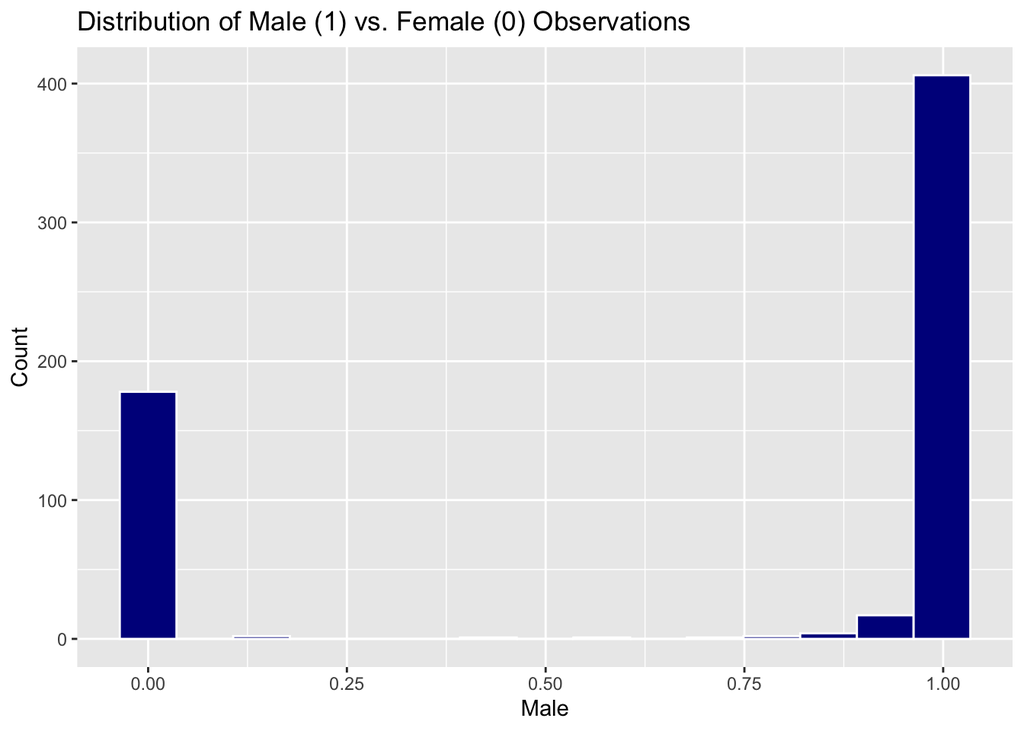

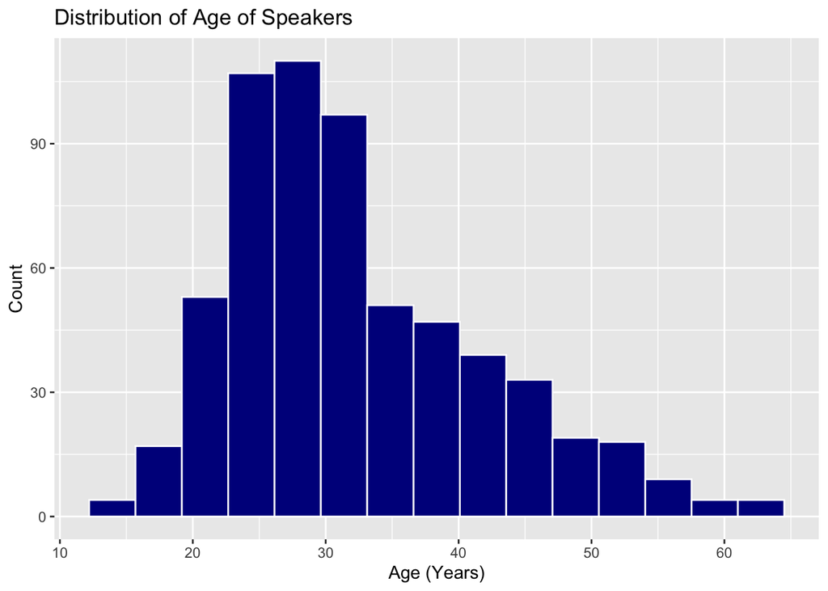

### 3.2 Distribution of our Outcome Variables

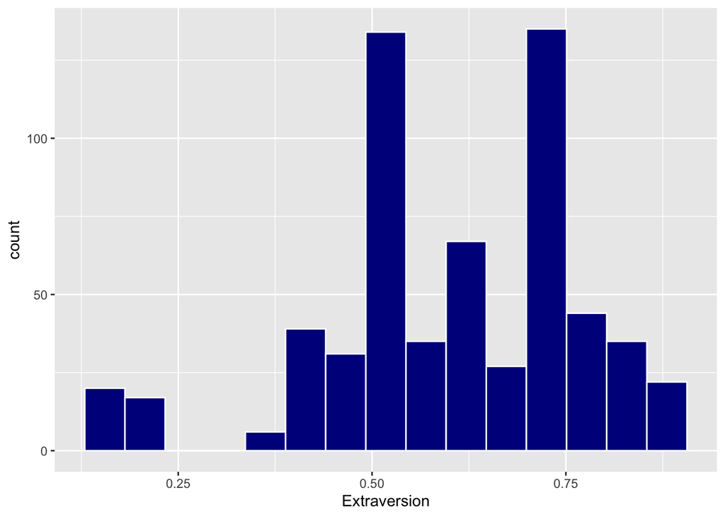

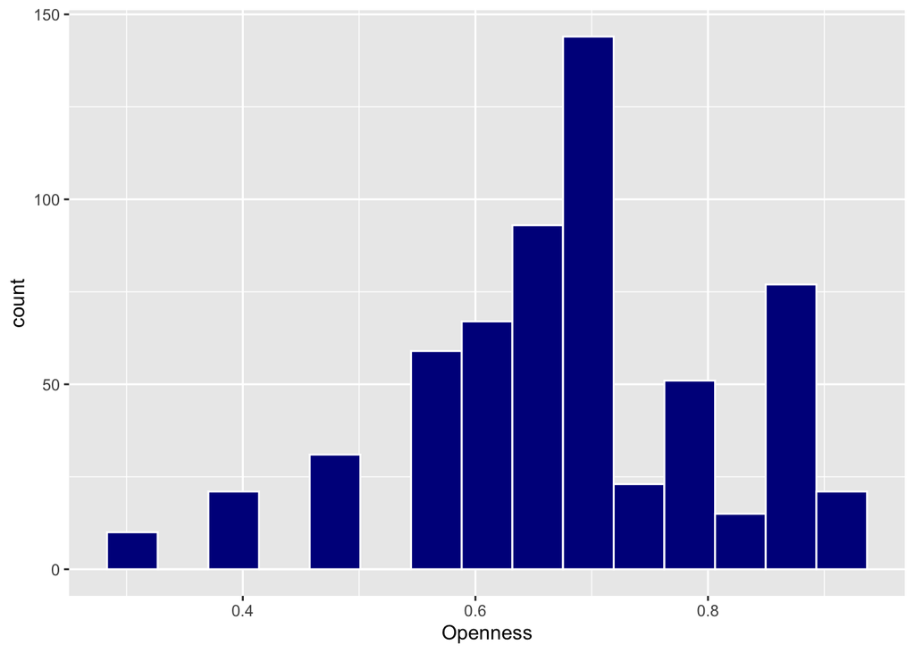

### 3.3 Correlation

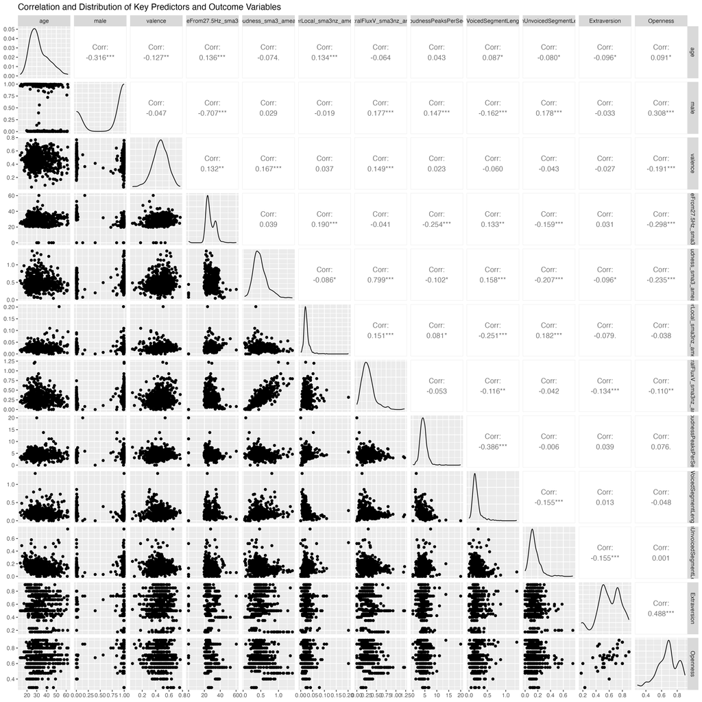